# IAV Risk Factor Analysis: BinaryPLSR (PLS-DA)

jonasalexandersteiner

2025-08-13

# Research Question & Hypothesis

This report investigates predictors (risk factors) for IAV positivity in swine farms using BinaryPLSR (PLS-DA). The hypothesis is that farm-level management, animal contact, and biosecurity variables are associated with IAV status.

## Data Source & Preprocessing

# PLS-DA Subset Analysis Overview

This report provides a separate PLS-DA analysis summary for each predictor subset:

- **Husbandry:** Farm management, biosecurity, and husbandry practices.
- **Animal Health:** Animal health status and performance.
- **Environment:** Environmental and housing conditions.
- **Human/Contact:** Human illness history and direct/indirect contacts.

## Husbandry Predictors

### Analysis Summary

- **Subset:** Husbandry
- **Sample Size:** 100
- **Predictors after filtering:** 116
- **Optimal number of components:** 1
- **Variance explained by each component:** 6.84, 6.55, 6.7 %
- **IAV Status Class Balance:**
  - Negative: 65 (65.0%)
  - Positive: 35 (35.0%)

### 1. PLS-DA Sample Scores Plot

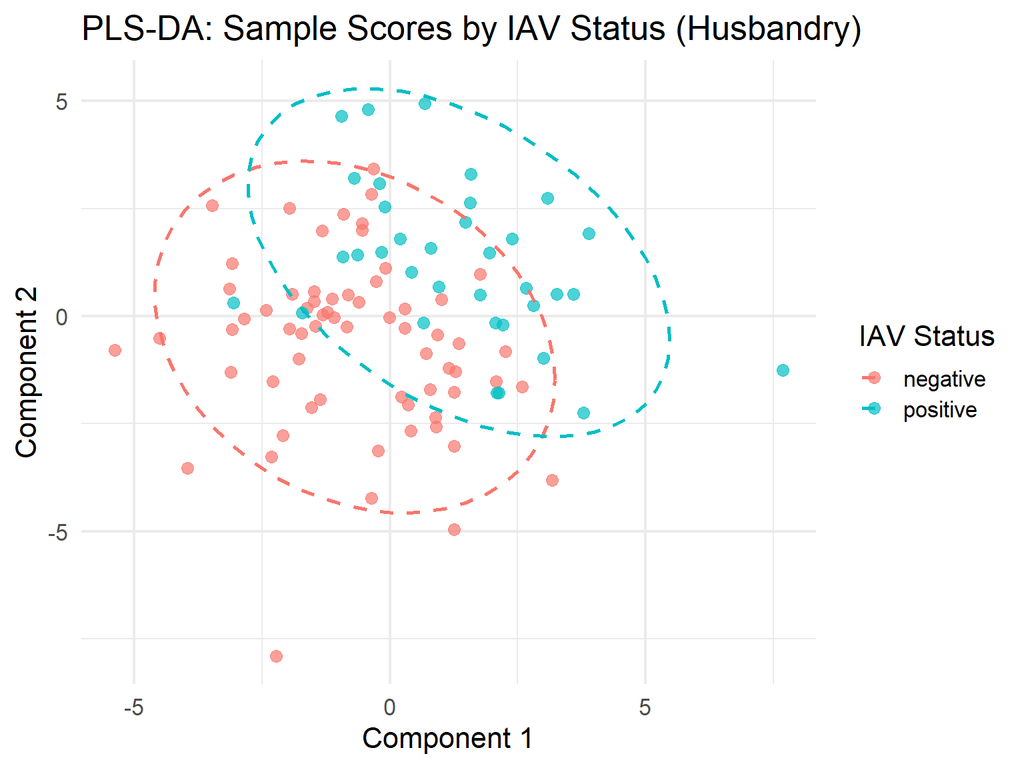

### 2. RMSEP Plot (Model Validation)

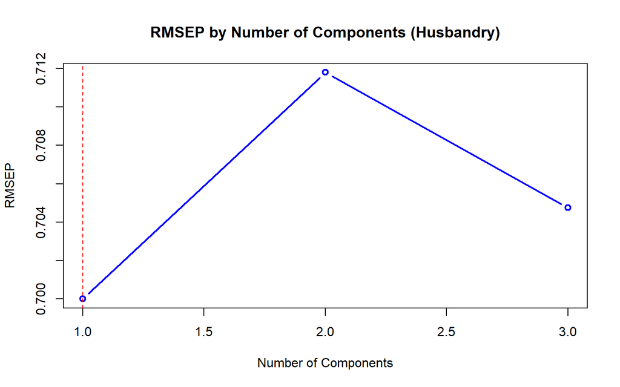

### 3. Risk and Protective Factors

#### Component 1 Risk/Protective Factors

|  | Predictor | Loading | Type |
| --- | --- | --- | --- |
| 1 | contact_bird_in_stable_TRUE | 0.3132417479356299 | Risk Factor |
| 2 | ai_airspace_with_other_agegroup_2 | 0.3000329153647415 | Risk Factor |
| 3 | ai_airspace_with_other_agegroup_1 | -0.1996021021082565 | Protective Factor |
| 4 | production_cycle_3 | 0.1895021115692071 | Risk Factor |
| 5 | cleaning_weaner_stable_FALSE | -0.1893402886090255 | Protective Factor |
| 6 | number_suckling_piglets | 0.1810773511071636 | Risk Factor |
| 7 | caretaker_entry_ppe_only_TRUE | 0.1725657047067213 | Risk Factor |
| 8 | bird_nests_FALSE | 0.1709665447655428 | Risk Factor |
| 9 | farrowing_airspace_with_other_agegroup_2 | 0.1658498032572312 | Risk Factor |
| 10 | cross_fostering_farrowing_stable_3 | 0.1655940846205132 | Risk Factor |

[output cut: 106 more lines]

#### Component 2 Risk/Protective Factors

|  | Predictor | Loading | Type |
| --- | --- | --- | --- |
| 1 | caretaker_ppe_stable_TRUE | -0.2012664153236118 | Protective Factor |
| 2 | cross_fostering_farrowing_stable_1 | 0.1882807802857758 | Risk Factor |
| 3 | caretaker_ppe_per_unit_TRUE | -0.1848170261054988 | Protective Factor |
| 4 | number_old_sows | -0.1783629168395706 | Protective Factor |
| 5 | herdsize | -0.1654083845228104 | Protective Factor |
| 6 | caretaker_ppe_washing_interval_FALSE | 0.1629296345095793 | Risk Factor |
| 7 | number_boars | -0.1625876959967361 | Protective Factor |
| 8 | number_weaners | -0.1624433318651084 | Protective Factor |
| 9 | contact_bird_in_stable_TRUE | 0.1612073018978144 | Risk Factor |
| 10 | caretaker_hands_washed_before_entry_TRUE | -0.1608642236975925 | Protective Factor |

[output cut: 106 more lines]

#### Variable Importance in Projection (VIP) Scores

|  | Predictor | VIP Score |
| --- | --- | --- |
| 1 | contact_bird_in_stable_TRUE | 3.373716874216503 |
| 2 | ai_airspace_with_other_agegroup_2 | 3.231453393608342 |
| 3 | ai_airspace_with_other_agegroup_1 | 2.149780431406902 |
| 4 | production_cycle_3 | 2.041000204200341 |
| 5 | cleaning_weaner_stable_FALSE | 2.039257317580028 |
| 6 | number_suckling_piglets | 1.950262757102871 |
| 7 | caretaker_entry_ppe_only_TRUE | 1.858589519810001 |
| 8 | bird_nests_FALSE | 1.841366040137574 |
| 9 | farrowing_airspace_with_other_agegroup_2 | 1.786257047542046 |
| 10 | cross_fostering_farrowing_stable_3 | 1.783502873536081 |

[output cut: 106 more lines]

### 4. Model Performance Summary

#### Confusion Matrix

Confusion Matrix

|  | FALSE | TRUE |
| --- | --- | --- |
| FALSE | 60 | 5 |
| TRUE | 16 | 19 |

#### Performance Metrics

Performance Metrics

| Metric | Value |
| --- | --- |
| Sensitivity | 0.543 |
| Specificity | 0.923 |
| Balanced Accuracy | 0.733 |
| AUC | 0.789 |

#### ROC Curve

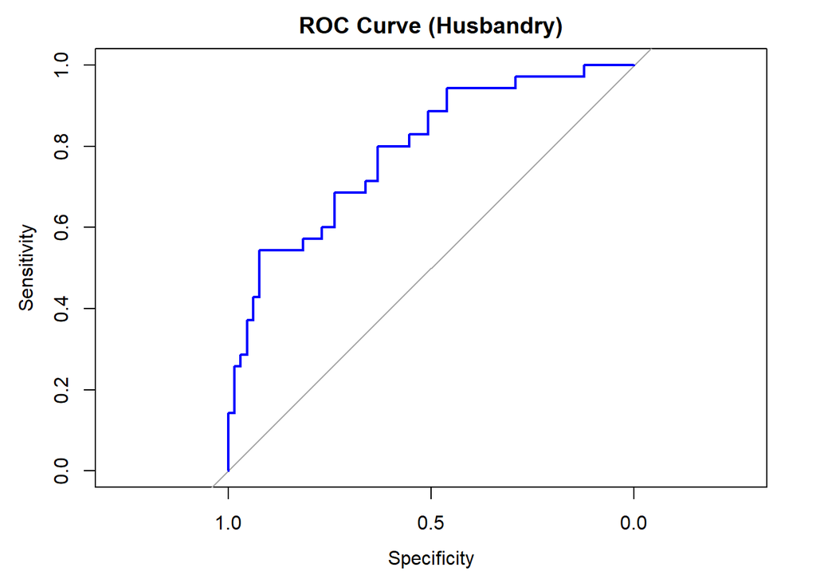

## Animal Health Predictors

### Analysis Summary

- **Subset:** Animal Health
- **Sample Size:** 100
- **Predictors after filtering:** 50
- **Optimal number of components:** 1
- **Variance explained by each component:** 7.47, 11.87, 4.33 %
- **IAV Status Class Balance:**
  - Negative: 65 (65.0%)
  - Positive: 35 (35.0%)

### 1. PLS-DA Sample Scores Plot

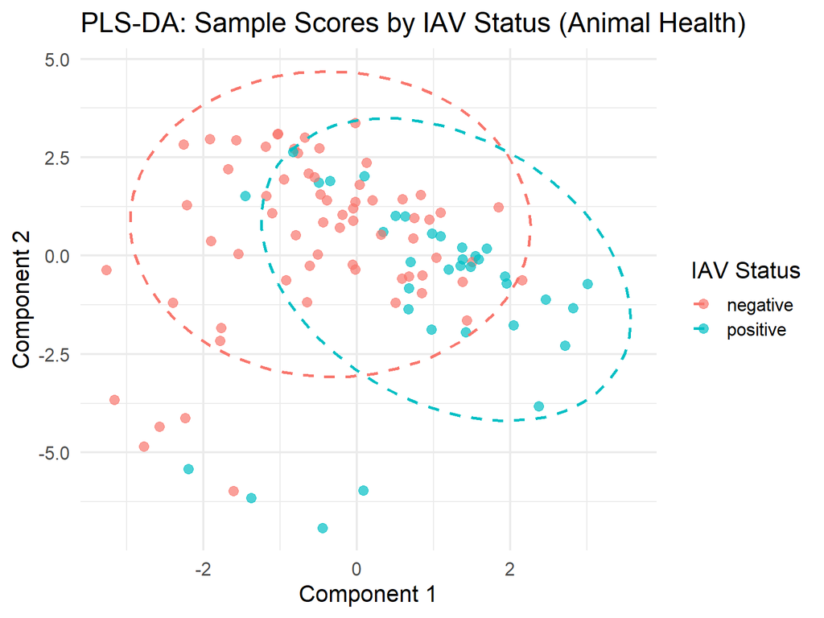

### 2. RMSEP Plot (Model Validation)

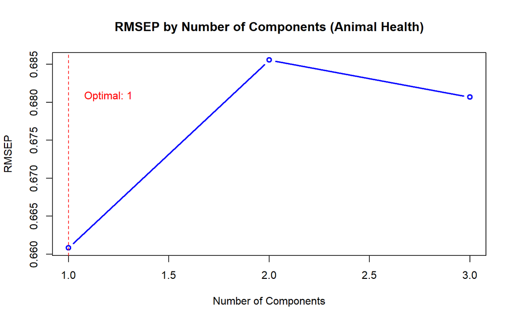

### 3. Risk and Protective Factors

#### Component 1 Risk/Protective Factors

|  | Predictor | Loading | Type |
| --- | --- | --- | --- |
| 1 | farrowing_piglet_litters_sneezing_TRUE | -0.322081601967513 | Protective Factor |
| 2 | farrowing_rate_TRUE | 0.2758430692172941 | Risk Factor |
| 3 | weaners_diseased_TRUE | 0.2660005853484638 | Risk Factor |
| 4 | symptom_swine_nasal_discharge_TRUE | 0.2491123810902564 | Risk Factor |
| 5 | symptom_swine_dyspnoea_TRUE | -0.2360968223333731 | Protective Factor |
| 6 | farrowing_rate_NA | -0.2103331993737736 | Protective Factor |
| 7 | piglets_per_sow_year_FALSE | -0.2065926478059281 | Protective Factor |
| 8 | respiratory_history_swine_NA | 0.2025834415690324 | Risk Factor |
| 9 | return_to_service_rate_TRUE | 0.1936721447381016 | Risk Factor |
| 10 | frequency_respi_outbreak_few pigs affected no outbreak | 0.1865218937842897 | Risk Factor |

[output cut: 40 more lines]

#### Component 2 Risk/Protective Factors

[output not shown]

[output cut: 40 more lines]

#### Variable Importance in Projection (VIP) Scores

|  | Predictor | VIP Score |
| --- | --- | --- |
| 1 | farrowing_piglet_litters_sneezing_TRUE | 2.277460848466549 |
| 2 | farrowing_rate_TRUE | 1.950505047868588 |
| 3 | weaners_diseased_TRUE | 1.880908176994897 |
| 4 | symptom_swine_nasal_discharge_TRUE | 1.761490539464478 |
| 5 | symptom_swine_dyspnoea_TRUE | 1.669456640885237 |
| 6 | farrowing_rate_NA | 1.487280315858574 |
| 7 | piglets_per_sow_year_FALSE | 1.460830622068559 |
| 8 | respiratory_history_swine_NA | 1.432481252895715 |
| 9 | return_to_service_rate_TRUE | 1.369468868712541 |
| 10 | frequency_respi_outbreak_few pigs affected no outbreak | 1.318908959346282 |

[output cut: 40 more lines]

### 4. Model Performance Summary

#### Confusion Matrix

Confusion Matrix

|  | FALSE | TRUE |
| --- | --- | --- |
| FALSE | 57 | 8 |
| TRUE | 15 | 20 |

#### Performance Metrics

Performance Metrics

| Metric | Value |
| --- | --- |
| Sensitivity | 0.571 |
| Specificity | 0.877 |
| Balanced Accuracy | 0.724 |
| AUC | 0.792 |

#### ROC Curve

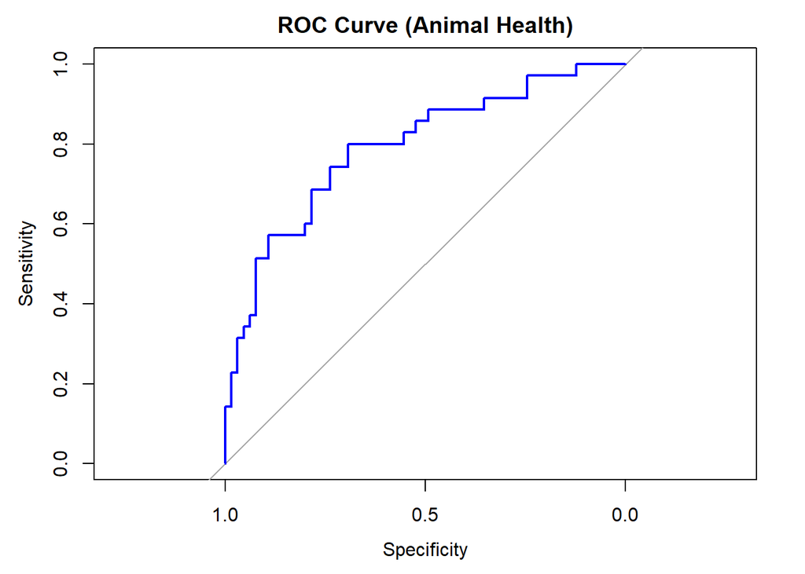

## Environment Predictors

### Analysis Summary

- **Subset:** Environment
- **Sample Size:** 100
- **Predictors after filtering:** 85
- **Optimal number of components:** 1
- **Variance explained by each component:** 5.46, 4.18, 7.42 %
- **IAV Status Class Balance:**
  - Negative: 65 (65.0%)
  - Positive: 35 (35.0%)

### 1. PLS-DA Sample Scores Plot

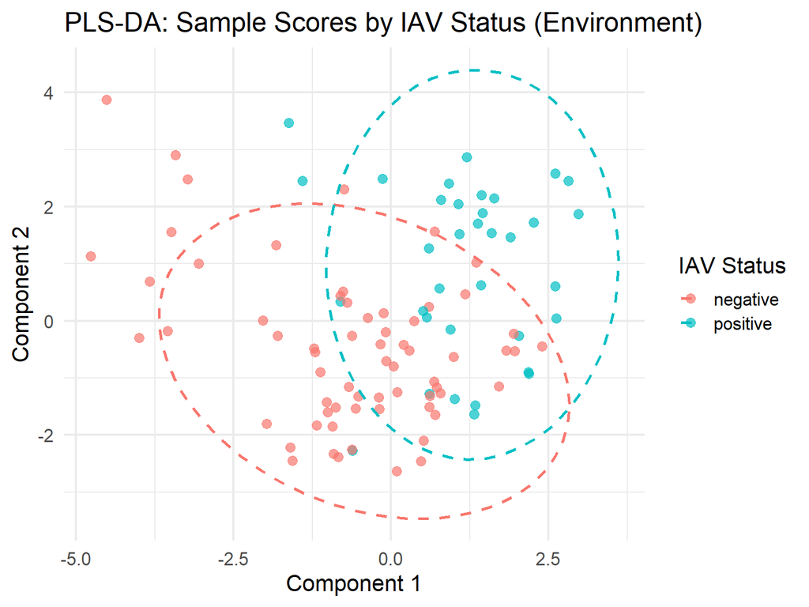

### 2. RMSEP Plot (Model Validation)

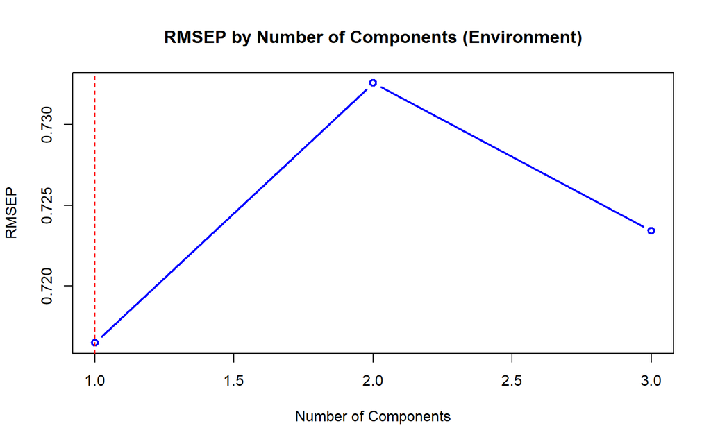

### 3. Risk and Protective Factors

#### Component 1 Risk/Protective Factors

|  | Predictor | Loading | Type |
| --- | --- | --- | --- |
| 1 | weaners_animals_per_feeding_site_factor_trough | -0.248865498278886 | Protective Factor |
| 2 | ai_sows_room_temperature_&gt;=24 | -0.231537403021411 | Protective Factor |
| 3 | gestation_sows_room_temperature_&gt;=25 | -0.231537403021411 | Protective Factor |
| 4 | gestation_sows_airflow_&gt;=0.4 | -0.2196337525948571 | Protective Factor |
| 5 | ai_sows_room_temperature_15–&lt;18 | 0.2077646420010907 | Risk Factor |
| 6 | ai_sows_airflow_&lt;0.1 | 0.1929121657498057 | Risk Factor |
| 7 | farrowing_room_temperature_&lt;17 | 0.1857048170599047 | Risk Factor |
| 8 | ai_sows_airflow_0.1–&lt;0.2 | -0.1828329411956294 | Protective Factor |
| 9 | weaners_room_temperature_NA | 0.180845135436675 | Risk Factor |
| 10 | season_sampling_autumn | 0.180845135436675 | Risk Factor |

[output cut: 75 more lines]

#### Component 2 Risk/Protective Factors

|  | Predictor | Loading | Type |
| --- | --- | --- | --- |
| 1 | fattening_pigs_room_temperature_&gt;=25 | 0.3056729484386339 | Risk Factor |
| 2 | farrowing_airflow_&gt;=0.4 | 0.2527073257344418 | Risk Factor |
| 3 | farrowing_room_temperature_&gt;26 | 0.2120188258927617 | Risk Factor |
| 4 | weaners_animals_per_water_source_&lt;10 | 0.2008915062187202 | Risk Factor |
| 5 | weaners_air_quality_1 | 0.1992837614263226 | Risk Factor |
| 6 | weaners_airflow_&gt;=0.4 | 0.1950776816563145 | Risk Factor |
| 7 | fattening_pigs_airflow_&gt;=0.4 | 0.1927266080722732 | Risk Factor |
| 8 | farrowing_room_temperature_&lt;17 | 0.1882039756879598 | Risk Factor |
| 9 | ai_sows_airflow_NA | -0.1870738769054035 | Protective Factor |
| 10 | weaners_qm_per_animal_0.4–&lt;0.6 | 0.1819231910449996 | Risk Factor |

[output cut: 75 more lines]

#### Variable Importance in Projection (VIP) Scores

|  | Predictor | VIP Score |
| --- | --- | --- |
| 1 | weaners_animals_per_feeding_site_factor_trough | 2.294426525268536 |
| 2 | ai_sows_room_temperature_&gt;=24 | 2.134669380682039 |
| 3 | gestation_sows_room_temperature_&gt;=25 | 2.134669380682039 |
| 4 | gestation_sows_airflow_&gt;=0.4 | 2.024923146370352 |
| 5 | ai_sows_room_temperature_15–&lt;18 | 1.915495353582596 |
| 6 | ai_sows_airflow_&lt;0.1 | 1.778562288482988 |
| 7 | farrowing_room_temperature_&lt;17 | 1.712113816817234 |
| 8 | ai_sows_airflow_0.1–&lt;0.2 | 1.685636429610722 |
| 9 | weaners_room_temperature_NA | 1.667309766043579 |
| 10 | season_sampling_autumn | 1.667309766043578 |

[output cut: 75 more lines]

### 4. Model Performance Summary

#### Confusion Matrix

Confusion Matrix

|  | FALSE | TRUE |
| --- | --- | --- |
| FALSE | 58 | 7 |
| TRUE | 14 | 21 |

#### Performance Metrics

Performance Metrics

| Metric | Value |
| --- | --- |
| Sensitivity | 0.600 |
| Specificity | 0.892 |
| Balanced Accuracy | 0.746 |
| AUC | 0.836 |

#### ROC Curve

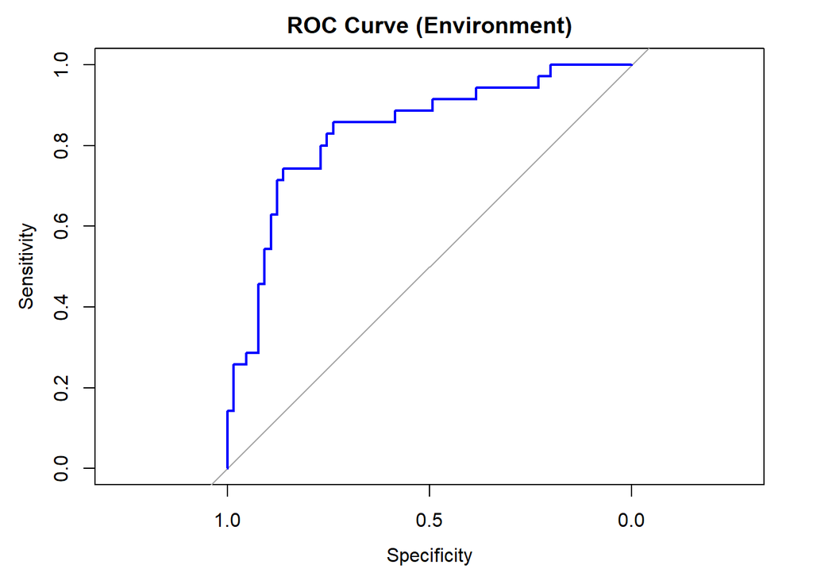

## Human/Contact Predictors

### Analysis Summary

- **Subset:** Human/Contact
- **Sample Size:** 100
- **Predictors after filtering:** 12
- **Optimal number of components:** 1
- **Variance explained by each component:** 15.92, 23.24, 8.62 %
- **IAV Status Class Balance:**
  - Negative: 65 (65.0%)
  - Positive: 35 (35.0%)

### 1. PLS-DA Sample Scores Plot

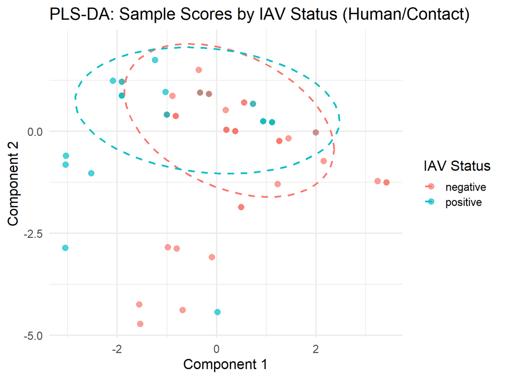

### 2. RMSEP Plot (Model Validation)

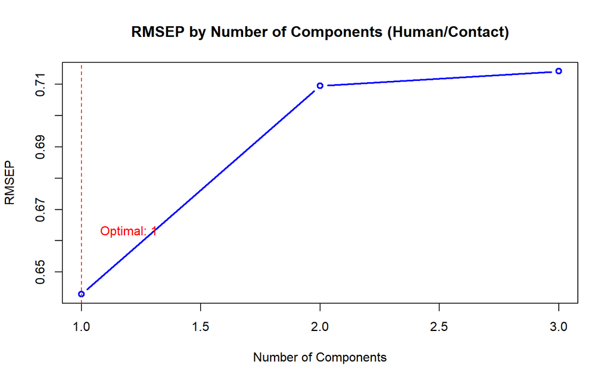

### 3. Risk and Protective Factors

#### Component 1 Risk/Protective Factors

[output not shown]

[output cut: 2 more lines]

#### Component 2 Risk/Protective Factors

|  | Predictor | Loading | Type |
| --- | --- | --- | --- |
| 1 | symptom_human_sneezing_TRUE | -0.5879266812612669 | Protective Factor |
| 2 | symptom_human_coughing_TRUE | -0.5793752423813832 | Protective Factor |
| 3 | respiratory_history_contact_person_TRUE | -0.3470259472646374 | Protective Factor |
| 4 | season_sampling_spring | 0.2926799136220239 | Risk Factor |
| 5 | season_sampling_winter | 0.2578566121886631 | Risk Factor |
| 6 | flu_vaccination_TRUE | -0.1182111574810379 | Protective Factor |
| 7 | season_sampling_autumn | -0.1097730122081776 | Protective Factor |
| 8 | chronic_disease_condition_TRUE | 0.0873518777325701 | Risk Factor |
| 9 | flu_vaccination_contacts_TRUE | 0.08054994389970976 | Risk Factor |
| 10 | symptom_severity_NA | 0.06489438111745806 | Risk Factor |

[output cut: 2 more lines]

#### Variable Importance in Projection (VIP) Scores

|  | Predictor | VIP Score |
| --- | --- | --- |
| 1 | season_sampling_autumn | 1.667202298676338 |
| 2 | flu_vaccination_TRUE | 1.263294324335227 |
| 3 | respiratory_history_human_TRUE | 1.23131050024945 |
| 4 | flu_vaccination_contacts_TRUE | 1.23131050024945 |
| 5 | chronic_disease_condition_TRUE | 1.153979626713427 |
| 6 | symptom_severity_NA | 1.111468199117559 |
| 7 | season_sampling_winter | 1.082858269512458 |
| 8 | season_sampling_spring | 0.8577685061079925 |
| 9 | smoker_TRUE | 0.2753888892502351 |
| 10 | symptom_human_sneezing_TRUE | 0.1368122778054945 |

[output cut: 2 more lines]

### 4. Model Performance Summary

#### Confusion Matrix

Confusion Matrix

|  | FALSE | TRUE |
| --- | --- | --- |
| FALSE | 61 | 4 |
| TRUE | 27 | 8 |

#### Performance Metrics

Performance Metrics

| Metric | Value |
| --- | --- |
| Sensitivity | 0.229 |
| Specificity | 0.938 |
| Balanced Accuracy | 0.584 |
| AUC | 0.631 |

#### ROC Curve

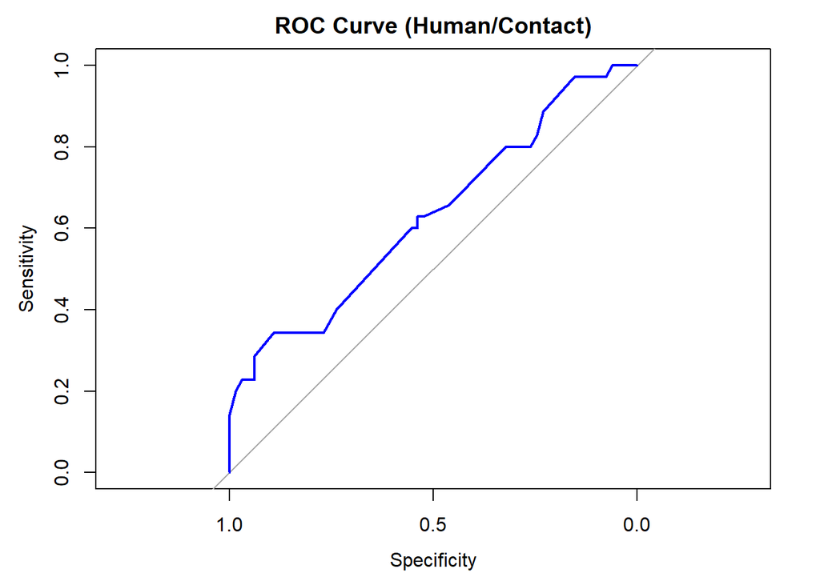

# Limitations

- Results depend on data preprocessing, filtering, and outcome coding (see logs for details).
- PLS-DA maximizes class separation rather than explained variance.
- Sample size and class imbalance may affect model stability.
- Component 2 may capture secondary patterns requiring further investigation.
- For very large datasets, further optimization (vectorized operations, data.table package) may be warranted.

# End of Report

If you have questions or wish to audit intermediate steps, please consult the logs and analysis script.